# **Airbnb Statistics Across New York City's 5 Boroughs**

# **Testing if Neighbourhood has an effect on the price via Mean and SD comparison**

> We want to see what the mean price and SD is for each neighborhood in New York, differing from the neighborhood group, or borough, from earlier. Then we will use a boxplot to determine whether there are any outliers and where the means lie in comparison to one another.

```
Mean prices:
neighbourhood
Allerton           636.255323
Arden Heights      804.888889
Arrochar           625.740203
Arverne            652.125561
Astoria            638.934849
                      ...
Windsor Terrace    580.291345
Woodhaven          630.516706
Woodlawn           587.137931
Woodrow            709.333333
Woodside           635.540099
Name: price, Length: 224, dtype: float64

Standard deviation of the means: 96.19560974175639
```

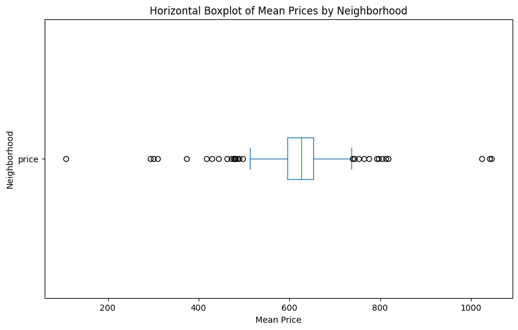

```python
# Finding the mean price for each of the 224 neighborhoods in New York
mean_prices = df.groupby('neighbourhood')['price'].mean()
print(f"Mean prices:\n{mean_prices}")
standard_deviation = mean_prices.std()
print(f"\nStandard deviation of the means: {standard_deviation}\n")
# Plotting the means on a box plot
plt.figure(figsize=(10, 6))
mean_prices.plot(kind='box', vert=False)
plt.title('Horizontal Boxplot of Mean Prices by Neighborhood')
plt.xlabel('Mean Price')
plt.ylabel('Neighborhood')
```

> **Conclusion**: After finding out the mean prices for all 224 neighborhoods, as well as the standard deviation, in the dataset, a boxplot helped conclude that there is in fact a large number outliers. This is not suprising as New York City is a massive area and the housing prices may vary significantly depending on the location. The boxplot fully encapsulates this notion, showing that there is a significant deviation between neighborhoods and their respective air bnb mean prices. Additionally, after finding out the standard deviation, which was around $96.20, it is evident that there is a large disparity between prices amongst the neighborhoods. This could signify a correlation between the neighborhood and the price as well.

# **Heatmap Correlation Matrix**

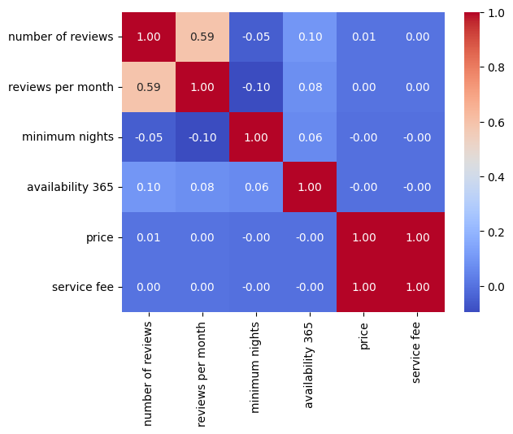

```python
import seaborn as sns

cols_i_want = ['number of reviews', 'reviews per month', 'minimum nights', 'availability 365', 'price', 'service fee']

corr_matrix = df[cols_i_want].corr()

sns.heatmap(corr_matrix, annot=True, fmt=".2f",cmap="coolwarm")
plt.show()
```

**Conclusion:**

This heatmap correlation matrix helps us draw conclusions through Pearson's correlation coefficient.

Another interesting discovery was the negative correlation (-0.10) between minimum nights and reviews per month. This is likely because places that require a higher minimum number of nights get reviewed less per month because guests have fewer opportunities to stay there.

The same can likely be said for minimum nights and number of reviews, but with a negative correlation of only -0.05 there is almost no significant relationship.

A surprising conclusion was that there is almost no correlation between the price of an Airbnb and its number of total reviews (0.01). We would expect that a more expensive place would have better amenities and more praised in the reviews than an average location, but clearly there is no relation between the two.

Lastly, we noticed a perfect 1 for correlation between price and service fee. This is because it is very likely that Airbnb sets a standard service fee which is a percentage of the total price.

# **Data Exploration Conclusion**

From our analysis, we have concluded many findings. From our Anova test, we found that the neighbourhood group/boroughs of New York City do not have an effect on the price of the airbnb location. This was quite a surprising find as we expected certain boroughs to be more popular. Additionally, from our Chi-Squared test we found that the neighbourhood group/New York City borough of an airbnb does not have an effect on whether or not an airbnb host is verified or not. So, the verification of the host must be based on the individual themselves. To add, from further analyzing the mean prices for the 224 neighbourhoods in our dataset, we found that there are a lot of outliers. This means that there is a lot of variation when it comes to the prices of airbnbs in varying neighbourhoods. This makes sense as the location of an airbnb seems likely to be a factor for the price as well as better located airbnbs might be priced higher. Moreover, we also analyzed the linear relationship between the numeric columns of our dataset via Pearson correlation coefficient. We found a positive correlation between the total number of reviews and the reviews per month and a slight negative correlation between minimum nights and reviews per month. There is also a very small negative correlation between minimum nights and number of reviews. There was also a perfect positive correlation as well between price and service fee, and this is most likely because airbnb has a standard service fee that is a certain percent of the price.

## Secondary Data Exploration

To make additional correlations, we had to stretch outside of our original dataset and seek out new data if we wanted to talk about the economy at all.

We wanted to discover additional findings in regards to our Airbnb data in relation to the New York City Boroughs. Particularly, we were interested in finding out if Airbnb changed their prices based on the salaries of the residents per borough. For example, if people in Staten Island had a higher mean salary, would this be reflected in Airbnb prices, resulting in higher Airbnb prices in Staten Island? As such, we will be analyzing the following [dataset](https://www.kaggle.com/datasets/ewilsonsd/nyc-payroll-data) to view the mean salaries of NYC residents per borough.

Printing this data reveals that it gives us each workers essential information about their job.

```python
# Here we are creating a new dataframe called df2 for our NYC Payroll Data
# and printing out the data to see the columns and types of values we are
# working with
df2 = pd.read_csv("k397-673e.csv")
df2
```

|  | fiscal_year | payroll_number | agency_name | last_name | first_name | mid_init | agency_start_date | work_location_borough | title_description | leave_status_as_of_july_31 | base_salary | pay_basis | regular_hours | regular_gross_paid | ot_hours | total_ot_paid | total_other_pay |
| --- | --- | --- | --- | --- | --- | --- | --- | --- | --- | --- | --- | --- | --- | --- | --- | --- | --- |
| 0 | 2020 | 67 | ADMIN FOR CHILDREN'S SVCS | ROSSELLI | DENISE | NaN | 2016-08-29T00:00:00.000 | MANHATTAN | PRINCIPAL ADMINISTRATIVE ASSOCIATE - NON SUPVR | CEASED | 55839.0 | per Annum | 0.00 | 639.81 | 0.00 | 5.62 | 0.00 |
| 1 | 2020 | 67 | ADMIN FOR CHILDREN'S SVCS | EPPS | ROY | L | 2019-06-24T00:00:00.000 | BRONX | YOUTH DEVELOPMENT SPECIALIST | CEASED | 45759.0 | per Annum | 876.25 | 20394.66 | 18.00 | 581.34 | 650.19 |
| 2 | 2020 | 67 | ADMIN FOR CHILDREN'S SVCS | MALACHI | DIAMOND | NaN | 2019-03-25T00:00:00.000 | BROOKLYN | YOUTH DEVELOPMENT SPECIALIST | ACTIVE | 45759.0 | per Annum | 1820.00 | 46665.35 | 443.25 | 15179.21 | 210.04 |
| 3 | 2020 | 67 | ADMIN FOR CHILDREN'S SVCS | SALVADOR JR | EFREN | V | 2016-06-20T00:00:00.000 | MANHATTAN | PRINCIPAL ADMINISTRATIVE ASSOCIATE - NON SUPVR | CEASED | 51778.0 | per Annum | 0.00 | 626.26 | 0.00 | 4.92 | 0.00 |
| 4 | 2020 | 67 | ADMIN FOR CHILDREN'S SVCS | BELLO | MELLY | D | 2006-12-11T00:00:00.000 | BROOKLYN | CHILD PROTECTIVE SPECIALIST SUPERVISOR | ACTIVE | 67392.0 | per Annum | 1820.00 | 63663.60 | 121.50 | 5240.36 | 4202.53 |
| ... | ... | ... | ... | ... | ... | ... | ... | ... | ... | ... | ... | ... | ... | ... | ... | ... | ... |
| 995 | 2020 | 67 | ADMIN FOR CHILDREN'S SVCS | HARRIS | TAMARA | NaN | 2005-01-24T00:00:00.000 | MANHATTAN | DIRECTOR OF FIELD OPERATIONS | ON LEAVE | 96295.0 | per Annum | 1150.00 | 59575.65 | 0.00 | 0.00 | 0.00 |
| 996 | 2020 | 67 | ADMIN FOR CHILDREN'S SVCS | URENA | TIFFANY | NaN | 2019-09-16T00:00:00.000 | MANHATTAN | AGENCY ATTORNEY INTERNE | ACTIVE | 71757.0 | per Annum | 1400.00 | 54691.23 | 25.00 | 1443.36 | 413.50 |
| 997 | 2020 | 67 | ADMIN FOR CHILDREN'S SVCS | FERMIN | DAISY | NaN | 2016-12-12T00:00:00.000 | MANHATTAN | ADMIN COMMUNITY RELATIONS SPECIALIST | CEASED | 66730.0 | per Annum | 1540.00 | 52377.52 | 0.00 | 0.00 | 8.25 |
| 998 | 2020 | 67 | ADMIN FOR CHILDREN'S SVCS | HERNANDEZ | ANA | M | 2004-01-26T00:00:00.000 | MANHATTAN | COMMUNITY ASSOCIATE | ACTIVE | 53315.0 | per Annum | 1820.00 | 46975.89 | 0.00 | 0.00 | 528.62 |
| 999 | 2020 | 67 | ADMIN FOR CHILDREN'S SVCS | CRUZ | ROSEMARY | NaN | 2004-06-28T00:00:00.000 | BROOKLYN | COMMUNITY ASSISTANT | ACTIVE | 37398.0 | per Annum | 1820.00 | 36823.81 | 174.50 | 4533.19 | 670.31 |

1000 rows × 17 columns

In order to compare the data we want consistency. So we need to make sure that the borough names fit the proper form that was used in the first dataset of our Airbnb data.

```python
# Here we are checking the possible borough values in the "work_location_borough"
# column to check for consistency and any data cleaning necessity.
df2["work_location_borough"].value_counts()
```

```
work_location_borough
MANHATTAN    518
BROOKLYN     216
BRONX        157
QUEENS        81
RICHMOND      28
Name: count, dtype: int64
```

We can see that the borough's are in all caps, which we would like to change for consistency with our first data set of "Airbnb_Open_Data.csv". Additionally, in this dataset, they use the term "RICHMOND" rather than "Staten Island," which are actually the same things. So, we need to change this term as well.

```python
# We are creating a mapping of how we will change the borough values in the
# "work_location_borough" column to fit our needs.
borough_mapping = {
    'MANHATTAN': 'Manhattan',
    'BROOKLYN': 'Brooklyn',
    'BRONX': 'Bronx',
    'QUEENS': 'Queens',
    'RICHMOND': 'Staten Island'
}

# We now replace the current values with the proper formatted ones
df2['work_location_borough'] = df2['work_location_borough'].replace(borough_mapping)

# Now we can see the changes made to the borough names was successful
print(df2['work_location_borough'].value_counts())
```

```
work_location_borough
Manhattan        518
Brooklyn         216
Bronx            157
Queens            81
Staten Island     28
Name: count, dtype: int64
```

The whole point of bringing in this data set was to get the mean salary of each borough, so to accomplish this we will take the mean of each base salary, grouped by their work location.

```python
# Now I would like to find the mean base salary for each borough to see which
# borough has a higher vs lower mean base salary
mean_base_salary_by_borough = df2.groupby('work_location_borough')['base_salary'].mean()

# First we are printing the mean base salaries per NYC borough,
# ordered from highest to lowest
print(mean_base_salary_by_borough.sort_values(ascending=False))

# We can compare the result above to the mean prices of Airbnbs by Borough
# and see if there is a correlation
mean_price_by_borough = df.groupby('neighbourhood group')['price'].mean()
print("\n")

# Now we will print out the mean Airbnb prices from our first dataset,
# also ordered from highest to lowest
print(mean_price_by_borough.sort_values(ascending=False))
```

```
work_location_borough
Manhattan        75383.858571
Staten Island    68976.821429
Queens           68223.827160
Brooklyn         61283.657407
Bronx            60808.229299
Name: base_salary, dtype: float64


neighbourhood group
Queens           630.242134
Bronx            627.538426
Brooklyn         626.530131
Staten Island    623.926812
Manhattan        622.403749
Name: price, dtype: float64
```

From above, we can see that the mean prices of Airbnbs based on NYC boroughs are fairly close in value. On the other hand, there is a significant different in mean base salaries based on NYC boroughs. Looking at the two sets of means, we can see an almost reverse correlation. For example, Manhattan has the highest mean base salary and the lowest mean Airbnb price. Additionally, Staten Island has the second highest mean base salary and the second lowest mean Airbnb price. The other three boroughs are also almost in reversed order similarly. Therefore, we can see that Airbnb does not necessarily account for people's salaries, such as how we initially expected for a higher salary area to equate to higher Airbnb prices. This is clearly not the case, and a possible explanation for this is that Airbnb doesn't base their prices too much on boroughs, and considers New York City as its own group/location, which is why the mean Airbnb prices based on boroughs are so close.

# **Primary Analysis and Machine Learning**

We are choosing supervised machine learning for our primary analysis. Because we want to determine which features have the most significance on whether an Airbnb will be rated well (> 3.0 stars), classification to determine the correct projected rating seems most appropriate in this scenario. We will need to determine which model will work best for our dataset and has the best accuracy among other scores such as recall, precision, and F1. The following machine learning section will go through the process of separating the data into training and testing data, one hot encoding the categorical variables, and using the stratified k fold technique for each model to validate and observe scores for Random Forest, Decision Tree, and Logistic Regression models.

```python
from sklearn.model_selection import train_test_split, cross_val_score, StratifiedKFold
from sklearn.preprocessing import OneHotEncoder
from sklearn.neighbors import KNeighborsClassifier
from sklearn.tree import DecisionTreeClassifier
from sklearn.linear_model import LogisticRegression
from sklearn.ensemble import RandomForestClassifier

X = df[['host_identity_verified', 'neighbourhood group', 'instant_bookable', 'cancellation_policy', 'room type']]
y = (df['review rate number'] > 3.0)

# Clean data by removing rows with any NaN values and aligning the y with the removed rows from X
mask = X.notna().all(axis=1)
X_clean = X[mask]
y_clean = y[mask]

# Splitting data into training and testing sets
seed = 42
X_train, X_test, y_train, y_test = train_test_split(X_clean, y_clean, test_size=0.3, random_state=seed)

# Encoding categorical variables with OneHotEncoder
encoder = OneHotEncoder(drop='first', sparse_output=False, handle_unknown='ignore')  # Add handle_unknown='ignore'
X_train_encoded = encoder.fit_transform(X_train)
X_test_encoded = encoder.transform(X_test)

# Define models
models = {
    'DecisionTree': DecisionTreeClassifier(),
    'Logistic Regression': LogisticRegression(),
    'Random Forest': RandomForestClassifier()
}

# Perform k-fold (5 fold) Cross-Validation for each model
k_folds = 5
skf = StratifiedKFold(n_splits=k_folds, shuffle=True, random_state=42)

for model_name, model in models.items():
    cross_val = cross_val_score(model, X_train_encoded, y_train, cv=skf)
    print(f"Model: {model_name}")
    print(f"Cross validation mean: {cross_val.mean()}")
    print(f"Cross validation accuracy std dev: {cross_val.std()}\n")
```

```
Model: DecisionTree
Cross validation mean: 0.5468931292374363
Cross validation accuracy std dev: 0.0016526194680792964

Model: Logistic Regression
Cross validation mean: 0.5471727126581393
Cross validation accuracy std dev: 8.387502621092223e-05

Model: Random Forest
Cross validation mean: 0.5468931292374363
Cross validation accuracy std dev: 0.0015800792508221058
```

As we observed, all cross validation means were nearly identical, with Decision Tree and Random Forest having similar standard deviations and Logistic Regression having a very small standard deviation which is good for cross validation.

```python
from sklearn.preprocessing import OneHotEncoder
from sklearn.metrics import accuracy_score, classification_report, confusion_matrix
print(f"Number of features in X_train_encoded: {X_train_encoded.shape[1]}")
print(f"Number of features in X_test_encoded: {X_test_encoded.shape[1]}")
# Train each model using the training data
for model_name, model in models.items():
    model.fit(X_train_encoded, y_train)

# Evaluate the performance of each model
for model_name, model in models.items():
    y_pred = model.predict(X_test_encoded)
    accuracy = accuracy_score(y_test, y_pred)
    print(f"Accuracy of {model_name}: {accuracy}")
    print(f"Classification Report for {model_name}:")
    print(classification_report(y_test, y_pred))
```

```
Number of features in X_train_encoded: 11
Number of features in X_test_encoded: 11
Accuracy of DecisionTree: 0.5357818513927849
Classification Report for DecisionTree:
              precision    recall  f1-score   support

       False       0.54      0.96      0.69     16524
        True       0.46      0.04      0.08     14134

    accuracy                           0.54     30658
   macro avg       0.50      0.50      0.38     30658
weighted avg       0.50      0.54      0.41     30658

Accuracy of Logistic Regression: 0.538978406941092
Classification Report for Logistic Regression:
              precision    recall  f1-score   support

       False       0.54      1.00      0.70     16524
        True       0.00      0.00      0.00     14134

    accuracy                           0.54     30658
   macro avg       0.27      0.50      0.35     30658
weighted avg       0.29      0.54      0.38     30658
```

[output not shown]

```
Accuracy of Random Forest: 0.5357818513927849
Classification Report for Random Forest:
              precision    recall  f1-score   support

       False       0.54      0.96      0.69     16524
        True       0.46      0.04      0.08     14134

    accuracy                           0.54     30658
   macro avg       0.50      0.50      0.38     30658
weighted avg       0.50      0.54      0.41     30658
```

```python
import numpy as np
# Retrieving and displaying the feature importances of the random forest model
feature_importance = models['Random Forest'].feature_importances_
feature_importance_df = pd.DataFrame({'Feature': encoder.get_feature_names_out(X.columns), 'Importance': feature_importance})
feature_importance_df = feature_importance_df.sort_values(by='Importance', ascending=False)

# Display top 7 features based on importance (absolute coefficients)
print(f"Top 7 features:\n {feature_importance_df.head(7)}")
```

```
Top 7 features:
                             Feature  Importance
0   host_identity_verified_verified    0.166214
7        cancellation_policy_strict    0.132791
5             instant_bookable_True    0.130364
6      cancellation_policy_moderate    0.115152
10            room type_Shared room    0.088495
9            room type_Private room    0.086265
2     neighbourhood group_Manhattan    0.065666
```

# **Machine Learning Visualization**

With the data trained and tested, our goal is to now determine which features from which we selected in the training model setup process have the most importance in our predictions. We will visualize the feature importance results from the previous section and create a bar plot to display all the features in order from most important to least important.

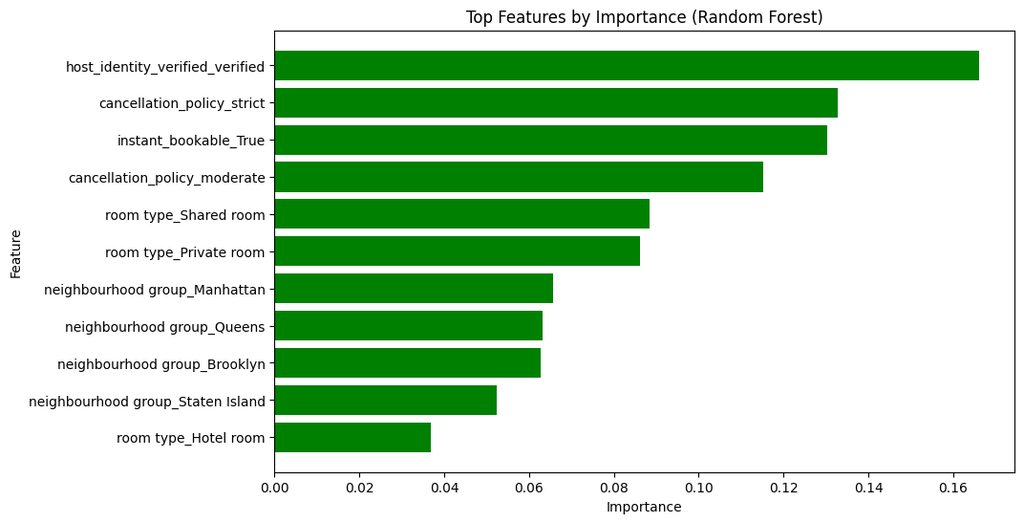

```python
# Visualizing feature importances
plt.figure(figsize=(10, 6))
top_features = feature_importance_df
plt.barh(top_features['Feature'], top_features['Importance'], color='green')
plt.xlabel('Importance')
plt.ylabel('Feature')
plt.title(f'Top Features by Importance (Random Forest)')
plt.gca().invert_yaxis()
plt.show()
```

We also want to see the confusion matrix for the model. This will help us determine what was correctly predicted positive, correctly predicted negative and vice versa for the falsely predicted positives and negatives. This is a good way to visualize accuracy scores for our model of choice, Random Forest.

[figure not shown]

```python
# Visualizing the confusion matrix for the dataset
from sklearn.metrics import confusion_matrix
import seaborn as sns

cm = confusion_matrix(y_test, y_pred)

plt.figure(figsize=(8, 6))
sns.heatmap(cm, annot=True, fmt='d', cmap='Blues', xticklabels=['Actual Negative', 'Actual Positive'], yticklabels=['Predicted Negative', 'Predicted Positive'])
plt.title('Confusion Matrix')
plt.xlabel('Actual')
plt.ylabel('Predicted')
plt.show()
```

# **Insights and Conclusions**

After analyzing our main dataset and secondary dataset, we were able to answer all our questions and learn more about the typical Airbnb listing, and about the economy of New York City and how the two relate. Most of our new knowledge that came from the Exploratory Data Analysis ended up being the opposite of what we expected. For instance, our ANOVA test showed us that the Airbnb price does not relate to the neighborhood group. Additionally, our Chi-Squared test revealed that the neighbourhood group of an airbnb does not have an effect on whether or not an airbnb host is verified or not. Other research that we tested with our data affirmed our predictions. Identifying means and standard deviations taught us that there is a lot of variation when it comes to the prices of airbnbs in varying neighbourhoods. Moreso, the linear relationships between the numeric columns of our dataset showed postitive and negative correlations that taught us about what factors play into the total number of reviews statistic.

We are glad to have explored this dataset, because otherwise we would've believed the misconception that the two correlate.

While we do feel we learned a lot about Airbnb and what characterstics tend to relate to a higher rating, a raise in price, or more often reviews, there is still much more to learn. We only covered the 5 boroughs of New York City, but these findings might not hold true for the rest of America or even other countries.

Given more time, we would compare many different cities and countries to discover if our trends are New York specific or seem to be the norm for all Airbnb listings.